# Analyzing Data from Pew’s 2017 Global Attitudes Survey

Rebecca Smith

3/24/2021

# INTRODUCTION

For this project, I will be doing another “guided” tutorial provided by medium.com (reference below). I’ve chosen to do this because I want to learn how to use the CRAN package “pewmethods”.

I will be analyzing data from the Pew Research Center’s spring 2017 Global Attitudes Survey, a poll that asks respondents in multiple countries about issues ranging from politics to economic conditions.

# DOWNLOAD AND INSTALL LIBRARIES

First, I will install the devtools package which will allow me to pull the pewmethods package from Pew’s github repo. For the subsequent analyses, I will also need tidyverse, haven, rworldmap, and ggrepel packages.

```r
library(devtools)
install_github("pewresearch/pewmethods", build_vignettes = TRUE, force = TRUE)
```

[output not shown]

```r
library(pewmethods)
library(tidyverse)
library(rworldmap)
library(ggrepel)
```

# DOWNLOAD DATASET

Next, I will import the Global Attitudes Spring 2017 Dataset and save it as “gap_rd”. This dataset contains more than 800 variables and 40,000 observations.

```r
library(haven)
gap_rd <- haven::read_sav("Pew-Research-Center-Spring-2017-Global-Attitudes-Survey_September-2018/Pew Research Global Attitudes Spring 2017 Dataset WEB FINAL.sav")
gap_rd
```

```
## # A tibble: 41,953 x 875
##       ID         survey    Country qsplit    desc_day country_satis  nostalgia50
##    <dbl>      <dbl+lbl>  <dbl+lbl> <dbl+>   <dbl+lbl>     <dbl+lbl>    <dbl+lbl>
##  1     1 1201702 [Spri~ 36 [Unite~     NA 2 [A parti~            NA 2 [Worse]
##  2     2 1201702 [Spri~ 36 [Unite~     NA 1 [A typic~            NA 1 [Better]
##  3     3 1201702 [Spri~ 36 [Unite~     NA 1 [A typic~            NA 1 [Better]
##  4     4 1201702 [Spri~ 36 [Unite~     NA 1 [A typic~            NA 2 [Worse]
##  5     5 1201702 [Spri~ 36 [Unite~     NA 1 [A typic~            NA 1 [Better]
##  6     6 1201702 [Spri~ 36 [Unite~     NA 3 [A parti~            NA 2 [Worse]
##  7     7 1201702 [Spri~ 36 [Unite~     NA 2 [A parti~            NA 2 [Worse]
##  8     8 1201702 [Spri~ 36 [Unite~     NA 2 [A parti~            NA 3 [About th~
##  9     9 1201702 [Spri~ 36 [Unite~     NA 1 [A typic~            NA 1 [Better]
## 10    10 1201702 [Spri~ 36 [Unite~     NA 2 [A parti~            NA 2 [Worse]
## # ... with 41,943 more rows, and 868 more variables: trust_gov <dbl+lbl>,
## #   econ_sit <dbl+lbl>, improve_econ <dbl+lbl>, personal_econ <dbl+lbl>,
## #   children_betteroff2 <dbl+lbl>, satisfied_democracy <dbl+lbl>,
## #   polsys_satisfied <dbl+lbl>, dem_stable <dbl+lbl>, fav_US <dbl+lbl>,
## #   fav_Americans <dbl+lbl>, fav_China <dbl+lbl>, fav_Iran <dbl+lbl>,
## #   fav_Russia <dbl+lbl>, fav_EU <dbl+lbl>, fav_Germany <dbl+lbl>,
## #   fav_Britain <dbl+lbl>, fav_NATO <dbl+lbl>, fav_India <dbl+lbl>,
## #   fav_Pak <dbl+lbl>, fav_Japan <dbl+lbl>, fav_Saudi <dbl+lbl>,
## #   fav_Turkey <dbl+lbl>, fav_SKorea <dbl+lbl>, fav_NKorea <dbl+lbl>,
## #   fav_Cuba <dbl+lbl>, fav_Boko <dbl+lbl>, fav_Mex <dbl+lbl>,
## #   country_respect <dbl+lbl>, partyfav_uk_conservative <dbl+lbl>,
## #   partyfav_uk_labour <dbl+lbl>, partyfav_uk_UKIP <dbl+lbl>,
## #   partyfav_uk_libDems <dbl+lbl>, partyfav_france_LesRepublicains <dbl+lbl>,
## #   partyfav_france_SocialistParty <dbl+lbl>,
## #   partyfav_france_FrontNational <dbl+lbl>,
## #   partyfav_france_PartideGauche <dbl+lbl>,
## #   partyfav_france_EnMarche <dbl+lbl>, partyfav_germany_CDU <dbl+lbl>,
## #   partyfav_germany_SPD <dbl+lbl>, partyfav_germany_AfD <dbl+lbl>,
## #   partyfav_germany_DieLinke <dbl+lbl>, partyfav_germany_NPD <dbl+lbl>,
## #   partyfav_greece_Syriza <dbl+lbl>, partyfav_greece_NewDemocracy <dbl+lbl>,
## #   partyfav_greece_DemCoal <dbl+lbl>, partyfav_greece_GoldenD <dbl+lbl>,
## #   partyfav_hungary_Fidesz <dbl+lbl>, partyfav_hungary_MSZP <dbl+lbl>,
## #   partyfav_hungary_JOBBIK <dbl+lbl>, partyfav_italy_Forza <dbl+lbl>,
## #   partyfav_italy_demParty <dbl+lbl>, partyfav_italy_5star <dbl+lbl>,
## #   partyfav_italy_LegaNord <dbl+lbl>, partyfav_italy_FdI <dbl+lbl>,
## #   partyfav_netherlands_vvd <dbl+lbl>, partyfav_netherlands_labour <dbl+lbl>,
## #   partyfav_netherlands_PVV <dbl+lbl>,
## #   partyfav_netherlands_socialist <dbl+lbl>, partyfav_poland_PiS <dbl+lbl>,
## #   partyfav_poland_PO <dbl+lbl>, partyfav_poland_kukiz <dbl+lbl>,
## #   partyfav_poland_nowoczesna <dbl+lbl>, partyfav_poland_PSL <dbl+lbl>,
## #   partyfav_spain_PP <dbl+lbl>, partyfav_spain_PSOE <dbl+lbl>,
## #   partyfav_spain_podemos <dbl+lbl>, partyfav_spain_Citizens <dbl+lbl>,
## #   partyfav_sweden_SAP <dbl+lbl>, partyfav_sweden_ModerateParty <dbl+lbl>,
## #   partyfav_sweden_SwedenDems <dbl+lbl>, swe_join_nato <dbl+lbl>,
## #   NAFTA_goodbad <dbl+lbl>, intthreat_chpower <dbl+lbl>,
## #   intthreat_USpower <dbl+lbl>, intthreat_ruspower <dbl+lbl>,
## #   intthreat_climatechange <dbl+lbl>, intthreat_isis <dbl+lbl>,
## #   intthreat_cyber <dbl+lbl>, intthreat_refugee <dbl+lbl>,
## #   intthreat_econcondition <dbl+lbl>, nato_def <dbl+lbl>,
## #   us_def_milforce <dbl+lbl>, concern_country <dbl+lbl>,
## #   turkey_eu_member <dbl+lbl>, neighboring_countries <dbl+lbl>,
## #   econ_power <dbl+lbl>, powerful_nation <dbl+lbl>, own_problems <dbl+lbl>,
## #   dissol_goodbad <dbl+lbl>, respect_china <dbl+lbl>, respect_us <dbl+lbl>,
## #   respect_france <dbl+lbl>, respect_russia <dbl+lbl>, global_trade <dbl+lbl>,
## #   global_movement <dbl+lbl>, global_culture <dbl+lbl>,
## #   global_money <dbl+lbl>, global_information <dbl+lbl>,
## #   polsys_directdemocracy <dbl+lbl>, polsys_republic <dbl+lbl>, ...
```

# SELECT VARIABLES OF INTEREST

For this project, we will examine two economically focused questions from the survey that were published in the report, “Global Publics More Upbeat About the Economy” (reference below). Because we will just be looking at two questions, I will first narrow down the dataset to the variables of interest: country (country variable), econ_sit (current economic situation in country), children_betteroff2 (will children be better off/worse off than parents), and weight (survey weights).

```r
gap2017 <- gap_rd %>%
  select(Country, econ_sit, children_betteroff2, weight) %>%
  haven::as_factor()
```

# TWO QUESTIONS

Now, we will explore two questions: 1. How did people view their country’s economic situation in 2017? 2. Did people think that children in their country would be better or worse off than their parents?

First, let’s identify the countries included in the survey, find the exact wording of the questions based on the SPSS labels, and get country-level estimates for these two questions of interest.

```r
unique(as.character(gap2017$Country))
```

```
##  [1] "United States"  "Mexico"         "Canada"         "Russia"
##  [5] "South Korea"    "United Kingdom" "France"         "Germany"
##  [9] "Netherlands"    "Spain"          "Sweden"         "Poland"
## [13] "Greece"         "Hungary"        "Italy"          "Japan"
## [17] "Australia"      "India"          "Indonesia"      "Philippines"
## [21] "Israel"         "Turkey"         "Argentina"      "Brazil"
## [25] "Chile"          "Colombia"       "Venezuela"      "Ghana"
## [29] "Kenya"          "Nigeria"        "South Africa"   "Senegal"
## [33] "Tunisia"        "Vietnam"        "Jordan"         "Lebanon"
## [37] "Tanzania"       "Peru"
```

38 countries were included in this dataset.

```r
get_spss_label(gap2017, c("econ_sit", "children_betteroff2"))
```

```
## [1] "Q5. Now thinking about our economic situation, how would you describe the current economic situation in (survey country) — is it very good, somewhat good, somewhat bad or very bad?"
## [2] "Q8. When children today in (survey country) grow up, do you think they will be better off or worse off financially than their parents?"
```

Alright, now we know that the econ_sit variable corresponds to Q5 which asks, “Now thinking about our economic situation, how would you describe the current economic situation in (survey country) - is it very good, somewhat good, somewhat bad or very bad?”. The children_betteroff2 variables corresponds to Q8, which asks, “When children today in (survey country) grow up, do you think they will be better off or worse off financially than their parents?”.

#CONVERT DATA

```r
econ_data_wide <- get_totals("econ_sit", gap2017, wt = "weight", by = "Country", na.rm = T, digits = 0)
head(econ_data_wide)
```

```
##                   econ_sit weight_name Argentina Australia Brazil Canada Chile
## 1                Very good      weight         5         6      0      5     4
## 2            Somewhat good      weight        18        54     15     54    41
## 3             Somewhat bad      weight        44        30     47     28    35
## 4                 Very bad      weight        29        10     35     10    19
## 5 Don’t know (DO NOT READ)      weight         3         1      3      2     1
## 6    Refused (DO NOT READ)      weight         1         0      0      0     0
##   Colombia France Germany Ghana Greece Hungary India Indonesia Israel Italy
## 1        3      0      31    11      0       1    30        14     14     1
## 2       31     21      55    35      2      41    53        49     48    14
## 3       36     55      12    14     26      43     8        32     31    51
## 4       29     23       1    37     72      13     4         5      7    32
## 5        1      0       1     3      0       2     5         1      1     1
## 6        0      0       0     0      0       0     0         0      0     0
##   Japan Jordan Kenya Lebanon Mexico Netherlands Nigeria Peru Philippines Poland
```

[output cut: 20 more lines]

The tutorial suggests that having the data in a long format, rather than wide, may help with analytic and graphing purposes. Below is the code I will use to attempt that:

```r
econ_data_long <- econ_data_wide %>%
  gather(country, economy, -one_of("econ_sit", "weight_name"), factor_key = T)
head(econ_data_long)
```

```
##                   econ_sit weight_name   country economy
## 1                Very good      weight Argentina       5
## 2            Somewhat good      weight Argentina      18
## 3             Somewhat bad      weight Argentina      44
## 4                 Very bad      weight Argentina      29
## 5 Don’t know (DO NOT READ)      weight Argentina       3
## 6    Refused (DO NOT READ)      weight Argentina       1
```

The tutorial explains that the team at Pew Research Center that examines this survey data typically collapses the responses into “good” and “bad” categories by adding rounded totals for very/somewhat good and very/somewhat bad. The code to replicate this is below. The spread function will be used to shape the dataset from long back to wide.

```r
econ_sit_collapse <- econ_data_long %>%
  mutate(econ_eval = case_when(
    econ_sit == "Very good" ~ "Good",
    econ_sit == "Somewhat good" ~ "Good",
    econ_sit == "Somewhat bad" ~ "Bad",
    econ_sit == "Very bad" ~ "Bad",
    TRUE ~ "DK/Refused"
  )) %>%
  group_by(country, econ_eval) %>%
  summarise(share = sum(economy))
final_econ <- econ_sit_collapse %>% spread(econ_eval, share)
head(final_econ[c("country", "Good", "Bad", "DK/Refused")])
```

```
## # A tibble: 6 x 4
## # Groups:   country [6]
##   country    Good   Bad `DK/Refused`
##   <fct>     <dbl> <dbl>        <dbl>
## 1 Argentina    23    73            4
## 2 Australia    60    40            1
## 3 Brazil       15    82            3
## 4 Canada       59    38            2
## 5 Chile        45    54            1
## 6 Colombia     34    65            1
```

# RECREATE MAP

The 2017 report includes a map (reference below) of the data that shows the share of respondents in each country who said the economic situation was good. Here is where the rworldmap package comes into play. Following the tutorial, I am going to try to recreate this map using said package.

```r
final_econ <- final_econ %>%
  mutate(econ_good_cat = case_when(
    Good < 20 ~ "<20%",
    Good %in% 20:34 ~ "20-34",
    Good %in% 35:49 ~ "35-49",
    Good %in% 50:64 ~ "50-64",
    Good %in% 65:80 ~ "60-80",
    Good > 80 ~ ">80%") %>%
  fct_relevel("<20%", "20-34", "35-49", "50-64", "65-80", ">80%")
  ) %>%
  ungroup
sPDF <- joinCountryData2Map(final_econ, joinCode = "NAME", nameJoinColumn = "country")
```

```
## 38 codes from your data successfully matched countries in the map
## 0 codes from your data failed to match with a country code in the map
## 205 codes from the map weren't represented in your data
```

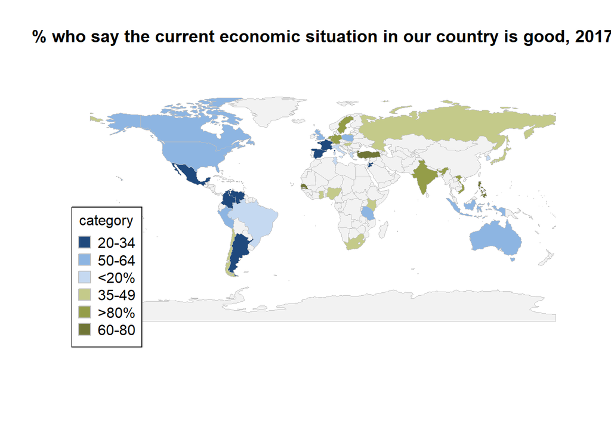

```r
mapCountryData(sPDF,
               nameColumnToPlot = "econ_good_cat",
               catMethod = "categorical",
               colourPalette = c("#1F497D", "#8DB5E2", "#C5D9F1", "#C4CA8A", "#949D48", "#707636"),
               mapTitle = "% who say the current economic situation in our country is good, 2017",
               missingCountryCol = "#F2F2F2")
```

# LOOKING AT CHILDREN BETTER/WORSE OFF IN EUROPEAN COUNTRIES

The survey includes a question that asks whether respondents think their children will be better or worse off financially than their parents. Let’s look at the positive and negative sides of the question for some European countries surveyed.

First, I have to filter the dataset.

```r
gap2017_EU <- gap2017 %>%
  filter(Country %in% c("United Kingdom", "France", "Germany", "Netherlands", "Spain", "Sweden", "Poland", "Greece", "Hungary", "Italy"))

children_data_wide <- get_totals("children_betteroff2",
                                 gap2017_EU, wt = "weight", by = "Country", na.rm = T, digits = 0)

children_data_long <- children_data_wide %>% gather(country, value, -one_of("children_betteroff2", "weight_name"), factor_key = T)

head(children_data_long)
```

```
##        children_betteroff2 weight_name country value
## 1               Better off      weight  France     9
## 2                Worse off      weight  France    71
## 3       Same (DO NOT READ)      weight  France    18
## 4 Don’t know (DO NOT READ)      weight  France     2
## 5    Refused (DO NOT READ)      weight  France     0
## 6               Better off      weight Germany    36
```

```r
sample_n(children_data_long, 10)
```

```
##         children_betteroff2 weight_name        country value
## 1        Same (DO NOT READ)      weight         Sweden     7
## 2                 Worse off      weight         Sweden    46
## 3        Same (DO NOT READ)      weight         France    18
## 4  Don’t know (DO NOT READ)      weight         Poland     8
## 5                Better off      weight          Italy    23
## 6                 Worse off      weight          Italy    65
## 7     Refused (DO NOT READ)      weight         France     0
## 8                 Worse off      weight United Kingdom    68
## 9     Refused (DO NOT READ)      weight         Poland     0
## 10                Worse off      weight          Spain    69
```

# CREATING BAR CHARTS

One of the reasons why I picked this tutorial is because I want to learn how to create accurate, succinct, and visually-appealing graphs to represent Pew data. This tutorial explains that the global attitudes team at Pew often displays the data in horizontal bar charts. To do this, we first need to manipulate the data in order to make a plot similar to those published in Pew reports. The bar chart will require both negative and positive values, so I will first create a new variable called children_bars that makes any “worse off” category negative while keeping the “better off” values positive. I will then mad the bar color to our graphic using “fill = children_betteroff2”. I can then use the new children_bars variable to sort the data based on the “better off” values.

To create the dataset I need for the graphic, I will filter the children_data_long dataframe to only the “better off” or “worse off” responses, pipe it to ggplot2 and customize the design of the graphic. The fct_reorder function will allow me to sort the data by the percent who say “better off” at the country level in descending order.

```r
#specify top margin
margin(t = 10)
```

```
## [1] 10points 0points  0points  0points
```

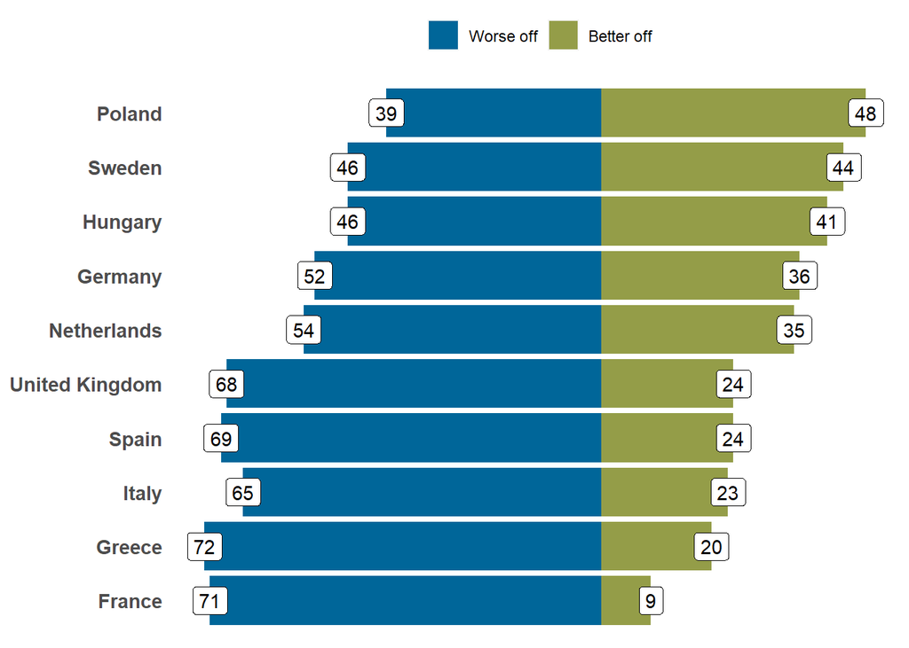

```r
p <- children_data_long %>%
  filter(!(children_betteroff2 %in% c("Don’t know (DO NOT READ)",
                                      "Same (DO NOT READ)",
                                      "Refused (DO NOT READ)")
  )) %>%
  mutate(
    children_bars = ifelse(children_betteroff2 == "Worse off", value * -1, value),
    children_betteroff2 = fct_relevel(children_betteroff2,
                                      "Worse off", "Better off"),
    better_only = ifelse(children_betteroff2 == "Better off", value, 0)
  ) %>%
  ggplot(
    aes(x = reorder(country, better_only),
        y = children_bars,
        fill = children_betteroff2,
        group = children_betteroff2
    )
  ) +
  geom_bar(stat = "identity") +
  geom_label(
    aes(
      label = abs(as.numeric(children_bars))

    ),
    fill = "white"
  ) +
  scale_fill_manual(values = c("Better off" = "#949D48", "Worse off" = "#006699")) +
  coord_flip() +
  theme(
    axis.line = element_blank(),
    panel.background = element_blank(),
    axis.ticks = element_blank(),
    legend.position = "top",
    legend.title = element_blank(),
    axis.title = element_blank(),
    axis.text.x = element_blank(),
    axis.text.y = element_text(size = 11, face = "bold")
  )
plot(p)
```

#REFERENCES Devlin, K. (2020, April 13). Analyzing international survey data with the pewmethods R package. Medium. https://medium.com/pew-research-center-decoded/analyzing-international-survey-data-with-the-pewmethods-r-package-3b0b21cba607